# Binary Classification Model for Caravan Insurance Marketing Using Python Take 2

### December 21, 2018

Template Credit: Adapted from a template made available by Dr. Jason Brownlee of Machine Learning Mastery. [https://machinelearningmastery.com/]

SUMMARY: The purpose of this project is to construct a prediction model using various machine learning algorithms and to document the end-to-end steps using a template. The Insurance Company Benchmark dataset is a classic binary classification situation where we are trying to predict one of the two possible outcomes.

INTRODUCTION: This data set was used in the CoIL 2000 Challenge that contains information on customers of an insurance company. The data consist of 86 variables and include product usage data and socio-demographic data derived from zip codes.

The data was supplied by the Dutch data mining company Sentient Machine Research and is based on a real-world business problem. The training set contains over 5000 descriptions of customers, including the information of whether they have a caravan insurance policy. A test dataset contains another 4000 customers whose information will be used to test the effectiveness of the machine learning models.

The insurance organization collected the data to answer the following question: Can we predict who would be interested in buying a caravan insurance policy and give an explanation why?

In iteration Take1, we had algorithms with high accuracy but with strong biases due to the imbalance of our dataset. For this iteration, we will examine the feasibility of using the SMOTE technique to balance the dataset.

ANALYSIS: From the previous Take1 iteration, the baseline performance of the eight algorithms achieved an average F1_Micro score of 0.9260. Two algorithms, Logistic Regression and Support Vector Machine, achieved the top F1_Micro scores after the first round of modeling. After a series of tuning trials, Support Vector Machine turned in the top result using the training data. It achieved an F1_Micro score of 0.9402. After using the optimized tuning parameters, the Support Vector Machine algorithm processed the validation dataset with an F1_Micro score of 0.9405, which was slightly better than using the training data.

From the current iteration, the baseline performance of the eight algorithms achieved an average F1_Micro score of 0.9326. Two algorithms, Random Forest and Extra Trees, achieved the top F1_Micro scores after the first round of modeling. After a series of tuning trials, Random Forest turned in the top result using the training data. It achieved an F1_Micro score of 0.9595. After using the optimized tuning parameters, the Random Forest algorithm processed the validation dataset with an F1_Micro score of 0.9165, which was noticeably worse than using the training data and perhaps due to overfitting.

CONCLUSION: For this iteration, the SMOTE technique improved the unbalanced dataset we have but did not improve the algorithm's final performance metric. Overall, the Random Forest algorithm achieved the leading F1_Micro scores using the training dataset, but the model failed to perform adequately using the validation dataset. For this dataset, Random Forest still should be considered for further modeling and testing before making it available for production use.

Dataset Used: Insurance Company Benchmark (COIL 2000) Data Set

Dataset ML Model: Binary classification with numerical and categorical attributes

Dataset Reference: https://archive.ics.uci.edu/ml/datasets/Insurance+Company+Benchmark+(COIL+2000)

One potential source of performance benchmark: https://www.kaggle.com/uciml/caravan-insurance-challenge

The project aims to touch on the following areas:

- Document a predictive modeling problem end-to-end.
- Explore data cleaning and transformation options
- Explore non-ensemble and ensemble algorithms for baseline model performance
- Explore algorithm tuning techniques for improving model performance

Any predictive modeling machine learning project genrally can be broken down into about six major tasks:

1. Prepare Problem
2. Summarize Data
3. Prepare Data
4. Model and Evaluate Algorithms
5. Improve Accuracy or Results
6. Finalize Model and Present Results

## Section 1 - Prepare Problem

### 1.a) Load ibraries

```python
import math
import numpy as np
import pandas as pd
import smtplib
from email.message import EmailMessage
from matplotlib import pyplot
from pandas import read_csv
from pandas import get_dummies
from pandas.plotting import scatter_matrix
from sklearn.preprocessing import StandardScaler
from sklearn.model_selection import train_test_split
from sklearn.model_selection import KFold
from sklearn.model_selection import cross_val_score
from sklearn.model_selection import GridSearchCV
from sklearn.metrics import accuracy_score
from sklearn.metrics import f1_score
from sklearn.metrics import confusion_matrix
from sklearn.metrics import classification_report
from sklearn.pipeline import Pipeline
from sklearn.linear_model import LogisticRegression
from sklearn.tree import DecisionTreeClassifier
from sklearn.neighbors import KNeighborsClassifier
from sklearn.discriminant_analysis import LinearDiscriminantAnalysis
from sklearn.naive_bayes import GaussianNB
from sklearn.svm import SVC
from sklearn.ensemble import BaggingClassifier
from sklearn.ensemble import RandomForestClassifier
from sklearn.ensemble import ExtraTreesClassifier
from sklearn.ensemble import AdaBoostClassifier
from sklearn.ensemble import GradientBoostingClassifier
from sklearn.externals.joblib import dump
from sklearn.externals.joblib import load
from sklearn.feature_selection import RFE
from datetime import datetime
from imblearn.over_sampling import SMOTE

# Create one random seed number for reproducible results
seedNum = 888
```

### 1.b) Set up the email notification function

```python
def email_notify(msg_text):
    sender = "luozhi2488@gmail.com"
    receiver = "dave@contactdavidlowe.com"
    with open('../email_credential.txt') as f:
        password = f.readline()
        f.close()
    msg = EmailMessage()
    msg.set_content(msg_text)
    msg['Subject'] = 'Notification from Python Script'
    msg['From'] = sender
    msg['To'] = receiver
    server = smtplib.SMTP('smtp.gmail.com', 587)
    server.starttls()
    server.login(sender, password)
    server.send_message(msg)
    server.quit()
```

```python
email_notify("Library and Data Loading has begun! "+datetime.now().strftime('%a %B %d, %Y %I:%M:%S %p'))
```

### 1.c) Load dataset

```python
startTimeScript = datetime.now()

# Read the list of attribute names from a file
attrFile = 'ticattributes.txt'
fhand = open(attrFile)
colNames = []
for line in fhand :
    colNames.append(line.split(' ', 1)[0])
print("Number of attribute names imported from the text file: ", len(colNames))

# Import the records for the training dataset
inputFile = 'ticdata2000.txt'
# xy_original_df = read_csv(inputFile, names=colNames)
xy_train_df = read_csv(inputFile, names=colNames, sep='\t')
print("Number of training rows and columns imported into xy_train_df: {}".format(xy_train_df.shape))

# Standardize the class column to the name of targetVar
#xy_original = xy_original.rename(columns={'some_name': 'targetVar'})
xy_train_df = xy_train_df.rename(columns={'CARAVAN': 'targetVar'})

# Import the records for the test/eval dataset without the target variable
inputFile = 'ticeval2000.txt'
colNames.remove('CARAVAN')
x_test_df = read_csv(inputFile, names=colNames, sep='\t')
print("Number of test/eval rows and columns imported into x_test_df: {}".format(x_test_df.shape))

# Import the records for the test/eval dataset without the target variable
inputFile = 'tictgts2000.txt'
colNames = []
colNames.append('targetVar')
y_test_df = read_csv(inputFile, names=colNames)
print("Number of test/eval target variable rows and columns imported into y_test_df: {}".format(y_test_df.shape))
```

```
Number of attribute names imported from the text file:  86
Number of training rows and columns imported into xy_train_df: (5822, 86)
Number of test/eval rows and columns imported into x_test_df: (4000, 85)
Number of test/eval target variable rows and columns imported into y_test_df: (4000, 1)
```

```python
# Use variable totCol to hold the number of columns in the dataframe
#totCol = len(xy_original_df.columns)
totCol = len(xy_train_df.columns)

# Set up variable totAttr for the total number of attribute columns
totAttr = totCol-1
```

```python
# targetCol variable indicates the column location of the target/class variable
# If the first column, set targetCol to 1. If the last column, set targetCol to totCol-1
# If (targetCol <> 1) and (targetCol <> totCol), be aware when slicing up the dataframes for visualization
targetCol = totCol-1
```

```python
# We create/manipulate training dataframes (xy_train_df, x_train_df, y_train_df) for various operations
# We create/manipulate validation dataframes (xy_test_df, x_test_df, y_test_df) for various operations

#x_original_df = xy_original_df.drop(columns=['targetVar'])
#y_original_df = xy_original_df['targetVar']
x_train_df = xy_train_df.drop(columns=['targetVar'])
y_train_df = xy_train_df[["targetVar"]]

# Use 70% of the data to train the models and the remaining for testing/validation
#validation_size = 0.30
#xy_train_df, xy_test_df = train_test_split(xy_original_df, test_size=validation_size, random_state=seedNum)
#x_train_df, x_test_df, y_train_df, y_test_df = train_test_split(x_original_df, y_original_df, test_size=validation_size, random_state=seedNum)

#print("x_original_df.shape: {} y_original_df.shape: {}".format(x_original_df.shape, y_original_df.shape))
print("x_train_df.shape: {} y_train_df.shape: {}".format(x_train_df.shape, y_train_df.shape))
print("x_test_df.shape: {} y_test_df.shape: {}".format(x_test_df.shape, y_test_df.shape))
```

```
x_train_df.shape: (5822, 85) y_train_df.shape: (5822, 1)
x_test_df.shape: (4000, 85) y_test_df.shape: (4000, 1)
```

### 1.d) Set up the key parameters to be used in the script

```python
# Set up the number of row and columns for visualization display. dispRow * dispCol should be >= totAttr
dispCol = 5
if totAttr % dispCol == 0 :
    dispRow = totAttr // dispCol
else :
    dispRow = (totAttr // dispCol) + 1

# Set figure width to 16 and height to 12 (4:3 aspect ratio)
fig_size = pyplot.rcParams["figure.figsize"]
fig_size[0] = 16
fig_size[1] = 12
pyplot.rcParams["figure.figsize"] = fig_size
```

```python
email_notify("Library and Data Loading completed! "+datetime.now().strftime('%a %B %d, %Y %I:%M:%S %p'))
```

## Section 2 - Summarize Data

To gain a better understanding of the data that we have on-hand, we will leverage a number of descriptive statistics and data visualization techniques. The plan is to use the results to consider new questions, review assumptions, and validate hypotheses that we can investigate later with specialized models.

```python
email_notify("Data Summarization and Visualization has begun! "+datetime.now().strftime('%a %B %d, %Y %I:%M:%S %p'))
```

### 2.a) Descriptive statistics

#### 2.a.i) Peek at the data itself.

```python
xy_train_df.head(10)
```

|  | MOSTYPE | MAANTHUI | MGEMOMV | MGEMLEEF | MOSHOOFD | MGODRK | MGODPR | MGODOV | MGODGE | MRELGE | ... | APERSONG | AGEZONG | AWAOREG | ABRAND | AZEILPL | APLEZIER | AFIETS | AINBOED | ABYSTAND | targetVar |
| --- | --- | --- | --- | --- | --- | --- | --- | --- | --- | --- | --- | --- | --- | --- | --- | --- | --- | --- | --- | --- | --- |
| 0 | 33 | 1 | 3 | 2 | 8 | 0 | 5 | 1 | 3 | 7 | ... | 0 | 0 | 0 | 1 | 0 | 0 | 0 | 0 | 0 | 0 |
| 1 | 37 | 1 | 2 | 2 | 8 | 1 | 4 | 1 | 4 | 6 | ... | 0 | 0 | 0 | 1 | 0 | 0 | 0 | 0 | 0 | 0 |
| 2 | 37 | 1 | 2 | 2 | 8 | 0 | 4 | 2 | 4 | 3 | ... | 0 | 0 | 0 | 1 | 0 | 0 | 0 | 0 | 0 | 0 |
| 3 | 9 | 1 | 3 | 3 | 3 | 2 | 3 | 2 | 4 | 5 | ... | 0 | 0 | 0 | 1 | 0 | 0 | 0 | 0 | 0 | 0 |
| 4 | 40 | 1 | 4 | 2 | 10 | 1 | 4 | 1 | 4 | 7 | ... | 0 | 0 | 0 | 1 | 0 | 0 | 0 | 0 | 0 | 0 |
| 5 | 23 | 1 | 2 | 1 | 5 | 0 | 5 | 0 | 5 | 0 | ... | 0 | 0 | 0 | 0 | 0 | 0 | 0 | 0 | 0 | 0 |
| 6 | 39 | 2 | 3 | 2 | 9 | 2 | 2 | 0 | 5 | 7 | ... | 0 | 0 | 0 | 0 | 0 | 0 | 0 | 0 | 0 | 0 |
| 7 | 33 | 1 | 2 | 3 | 8 | 0 | 7 | 0 | 2 | 7 | ... | 0 | 0 | 0 | 0 | 0 | 0 | 0 | 0 | 0 | 0 |
| 8 | 33 | 1 | 2 | 4 | 8 | 0 | 1 | 3 | 6 | 6 | ... | 0 | 0 | 0 | 0 | 0 | 0 | 0 | 0 | 0 | 0 |
| 9 | 11 | 2 | 3 | 3 | 3 | 3 | 5 | 0 | 2 | 7 | ... | 0 | 0 | 0 | 1 | 0 | 0 | 0 | 0 | 0 | 0 |

10 rows × 86 columns

#### 2.a.ii) Dimensions of the dataset.

```python
xy_train_df.shape
```

```
(5822, 86)
```

#### 2.a.iii) Types of the attributes.

```python
xy_train_df.dtypes
```

```
MOSTYPE      int64
MAANTHUI     int64
MGEMOMV      int64
MGEMLEEF     int64
MOSHOOFD     int64
MGODRK       int64
MGODPR       int64
MGODOV       int64
MGODGE       int64
MRELGE       int64
MRELSA       int64
MRELOV       int64
MFALLEEN     int64
MFGEKIND     int64
MFWEKIND     int64
MOPLHOOG     int64
MOPLMIDD     int64
MOPLLAAG     int64
MBERHOOG     int64
MBERZELF     int64
MBERBOER     int64
MBERMIDD     int64
MBERARBG     int64
MBERARBO     int64
MSKA         int64
MSKB1        int64
MSKB2        int64
MSKC         int64
MSKD         int64
MHHUUR       int64
             ...
PGEZONG      int64
PWAOREG      int64
PBRAND       int64
PZEILPL      int64
PPLEZIER     int64
PFIETS       int64
PINBOED      int64
PBYSTAND     int64
AWAPART      int64
AWABEDR      int64
AWALAND      int64
APERSAUT     int64
ABESAUT      int64
AMOTSCO      int64
AVRAAUT      int64
AAANHANG     int64
ATRACTOR     int64
AWERKT       int64
ABROM        int64
ALEVEN       int64
APERSONG     int64
AGEZONG      int64
AWAOREG      int64
ABRAND       int64
AZEILPL      int64
APLEZIER     int64
AFIETS       int64
AINBOED      int64
ABYSTAND     int64
targetVar    int64
Length: 86, dtype: object
```

#### 2.a.iv) Statistical summary of all attributes.

```python
xy_train_df.describe()
```

|  | MOSTYPE | MAANTHUI | MGEMOMV | MGEMLEEF | MOSHOOFD | MGODRK | MGODPR | MGODOV | MGODGE | MRELGE | ... | APERSONG | AGEZONG | AWAOREG | ABRAND | AZEILPL | APLEZIER | AFIETS | AINBOED | ABYSTAND | targetVar |
| --- | --- | --- | --- | --- | --- | --- | --- | --- | --- | --- | --- | --- | --- | --- | --- | --- | --- | --- | --- | --- | --- |
| count | 5822.000000 | 5822.000000 | 5822.000000 | 5822.000000 | 5822.000000 | 5822.000000 | 5822.000000 | 5822.000000 | 5822.000000 | 5822.000000 | ... | 5822.000000 | 5822.000000 | 5822.000000 | 5822.000000 | 5822.000000 | 5822.000000 | 5822.000000 | 5822.000000 | 5822.000000 | 5822.000000 |
| mean | 24.253349 | 1.110615 | 2.678805 | 2.991240 | 5.773617 | 0.696496 | 4.626932 | 1.069907 | 3.258502 | 6.183442 | ... | 0.005325 | 0.006527 | 0.004638 | 0.570079 | 0.000515 | 0.006012 | 0.031776 | 0.007901 | 0.014256 | 0.059773 |
| std | 12.846706 | 0.405842 | 0.789835 | 0.814589 | 2.856760 | 1.003234 | 1.715843 | 1.017503 | 1.597647 | 1.909482 | ... | 0.072782 | 0.080532 | 0.077403 | 0.562058 | 0.022696 | 0.081632 | 0.210986 | 0.090463 | 0.119996 | 0.237087 |
| min | 1.000000 | 1.000000 | 1.000000 | 1.000000 | 1.000000 | 0.000000 | 0.000000 | 0.000000 | 0.000000 | 0.000000 | ... | 0.000000 | 0.000000 | 0.000000 | 0.000000 | 0.000000 | 0.000000 | 0.000000 | 0.000000 | 0.000000 | 0.000000 |
| 25% | 10.000000 | 1.000000 | 2.000000 | 2.000000 | 3.000000 | 0.000000 | 4.000000 | 0.000000 | 2.000000 | 5.000000 | ... | 0.000000 | 0.000000 | 0.000000 | 0.000000 | 0.000000 | 0.000000 | 0.000000 | 0.000000 | 0.000000 | 0.000000 |
| 50% | 30.000000 | 1.000000 | 3.000000 | 3.000000 | 7.000000 | 0.000000 | 5.000000 | 1.000000 | 3.000000 | 6.000000 | ... | 0.000000 | 0.000000 | 0.000000 | 1.000000 | 0.000000 | 0.000000 | 0.000000 | 0.000000 | 0.000000 | 0.000000 |
| 75% | 35.000000 | 1.000000 | 3.000000 | 3.000000 | 8.000000 | 1.000000 | 6.000000 | 2.000000 | 4.000000 | 7.000000 | ... | 0.000000 | 0.000000 | 0.000000 | 1.000000 | 0.000000 | 0.000000 | 0.000000 | 0.000000 | 0.000000 | 0.000000 |
| max | 41.000000 | 10.000000 | 5.000000 | 6.000000 | 10.000000 | 9.000000 | 9.000000 | 5.000000 | 9.000000 | 9.000000 | ... | 1.000000 | 1.000000 | 2.000000 | 7.000000 | 1.000000 | 2.000000 | 3.000000 | 2.000000 | 2.000000 | 1.000000 |

8 rows × 86 columns

#### 2.a.v) Count missing values.

```python
xy_train_df.isnull().sum()
```

```
MOSTYPE      0
MAANTHUI     0
MGEMOMV      0
MGEMLEEF     0
MOSHOOFD     0
MGODRK       0
MGODPR       0
MGODOV       0
MGODGE       0
MRELGE       0
MRELSA       0
MRELOV       0
MFALLEEN     0
MFGEKIND     0
MFWEKIND     0
MOPLHOOG     0
MOPLMIDD     0
MOPLLAAG     0
MBERHOOG     0
MBERZELF     0
MBERBOER     0
MBERMIDD     0
MBERARBG     0
MBERARBO     0
MSKA         0
MSKB1        0
MSKB2        0
MSKC         0
MSKD         0
MHHUUR       0
            ..
PGEZONG      0
PWAOREG      0
PBRAND       0
PZEILPL      0
PPLEZIER     0
PFIETS       0
PINBOED      0
PBYSTAND     0
AWAPART      0
AWABEDR      0
AWALAND      0
APERSAUT     0
ABESAUT      0
AMOTSCO      0
AVRAAUT      0
AAANHANG     0
ATRACTOR     0
AWERKT       0
ABROM        0
ALEVEN       0
APERSONG     0
AGEZONG      0
AWAOREG      0
ABRAND       0
AZEILPL      0
APLEZIER     0
AFIETS       0
AINBOED      0
ABYSTAND     0
targetVar    0
Length: 86, dtype: int64
```

#### 2.a.vi) Summarize the levels of the class attribute.

```python
xy_train_df.groupby('targetVar').size()
```

```
targetVar
0    5474
1     348
dtype: int64
```

### 2.b) Data visualizations

##### 2.b.i) Univariate plots to better understand each attribute

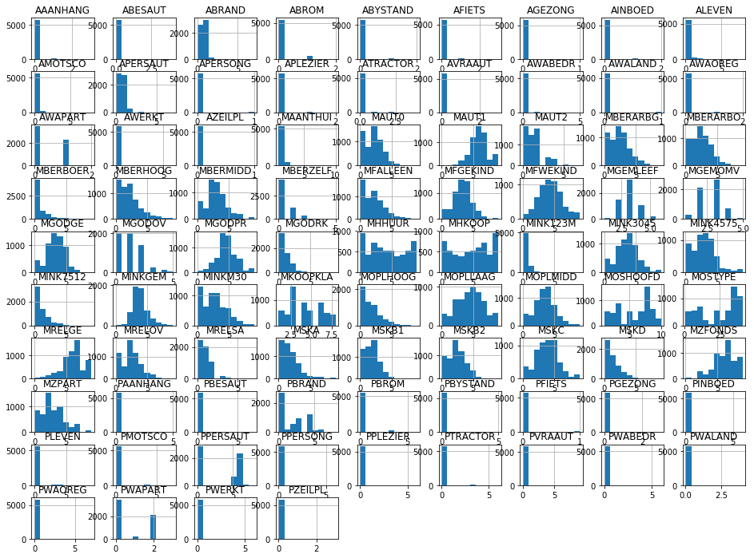

```python
# Histograms for each attribute
x_train_df.hist()
pyplot.show()
```

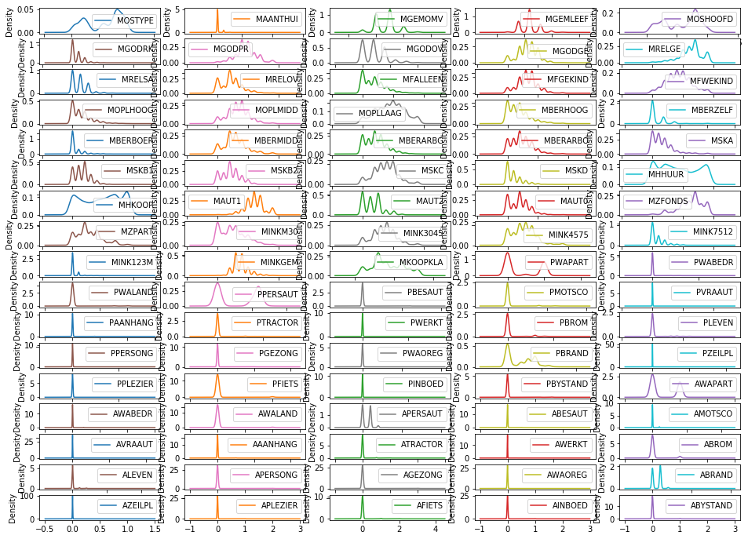

```python
# Density plot for each attribute
x_train_df.plot(kind='density', subplots=True, layout=(dispRow,dispCol), sharex=False, sharey=False)
pyplot.show()
```

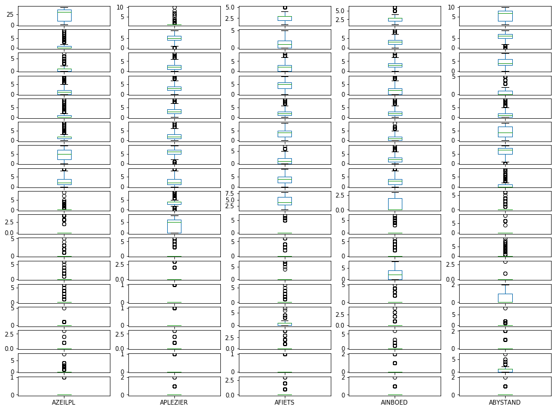

```python
# Box and Whisker plot for each attribute
x_train_df.plot(kind='box', subplots=True, layout=(dispRow,dispCol), sharex=False, sharey=False)
pyplot.show()
```

#### 2.b.ii) Multivariate plots to better understand the relationships between attributes

```python
# Scatterplot matrix
#scatter_matrix(x_train_df)
#pyplot.show()
```

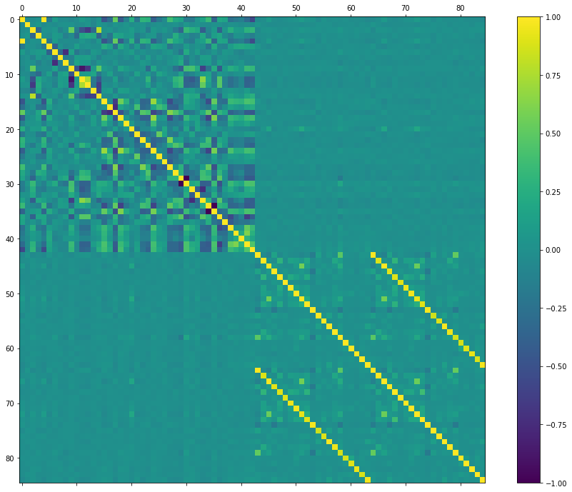

```python
# Correlation matrix
fig = pyplot.figure()
ax = fig.add_subplot(111)
cax = ax.matshow(x_train_df.corr(), vmin=-1, vmax=1)
fig.colorbar(cax)
pyplot.show()
```

```python
email_notify("Data Summarization and Visualization completed! "+datetime.now().strftime('%a %B %d, %Y %I:%M:%S %p'))
```

## Section 3 - Prepare Data

Some dataset may require additional preparation activities that will best exposes the structure of the problem and the relationships between the input attributes and the output variable. Some data-prep tasks might include:

- Cleaning data by removing duplicates, marking missing values and even imputing missing values.
- Feature selection where redundant features may be removed.
- Data transforms where attributes are scaled or redistributed in order to best expose the structure of the problem later to learning algorithms.

```python
email_notify("Data Cleaning and Transformation has begun! "+datetime.now().strftime('%a %B %d, %Y %I:%M:%S %p'))
```

### 3.a) Data Cleaning

```python
# According to the data dictionary, columns MOSTYPE and MOSHOOFD should be converted to categorical type
x_train_df['MOSTYPE'] = x_train_df['MOSTYPE'].astype('category')
x_train_df['MOSHOOFD'] = x_train_df['MOSHOOFD'].astype('category')

# Apply the One-Hot-Encoding (dummy variable handling) technique
x_train_df = get_dummies(x_train_df)
print(x_train_df.dtypes)
```

```
MAANTHUI       int64
MGEMOMV        int64
MGEMLEEF       int64
MGODRK         int64
MGODPR         int64
MGODOV         int64
MGODGE         int64
MRELGE         int64
MRELSA         int64
MRELOV         int64
MFALLEEN       int64
MFGEKIND       int64
MFWEKIND       int64
MOPLHOOG       int64
MOPLMIDD       int64
MOPLLAAG       int64
MBERHOOG       int64
MBERZELF       int64
MBERBOER       int64
MBERMIDD       int64
MBERARBG       int64
MBERARBO       int64
MSKA           int64
MSKB1          int64
MSKB2          int64
MSKC           int64
MSKD           int64
MHHUUR         int64
MHKOOP         int64
MAUT1          int64
               ...
MOSTYPE_22     uint8
MOSTYPE_23     uint8
MOSTYPE_24     uint8
MOSTYPE_25     uint8
MOSTYPE_26     uint8
MOSTYPE_27     uint8
MOSTYPE_28     uint8
MOSTYPE_29     uint8
MOSTYPE_30     uint8
MOSTYPE_31     uint8
MOSTYPE_32     uint8
MOSTYPE_33     uint8
MOSTYPE_34     uint8
MOSTYPE_35     uint8
MOSTYPE_36     uint8
MOSTYPE_37     uint8
MOSTYPE_38     uint8
MOSTYPE_39     uint8
MOSTYPE_40     uint8
MOSTYPE_41     uint8
MOSHOOFD_1     uint8
MOSHOOFD_2     uint8
MOSHOOFD_3     uint8
MOSHOOFD_4     uint8
MOSHOOFD_5     uint8
MOSHOOFD_6     uint8
MOSHOOFD_7     uint8
MOSHOOFD_8     uint8
MOSHOOFD_9     uint8
MOSHOOFD_10    uint8
Length: 133, dtype: object
```

```python
# According to the data dictionary, columns MOSTYPE and MOSHOOFD should be converted to categorical type
x_test_df['MOSTYPE'] = x_test_df['MOSTYPE'].astype('category')
x_test_df['MOSHOOFD'] = x_test_df['MOSHOOFD'].astype('category')

# Apply the One-Hot-Encoding (dummy variable handling) technique
x_test_df = get_dummies(x_test_df)
print(x_test_df.dtypes)
```

```
MAANTHUI       int64
MGEMOMV        int64
MGEMLEEF       int64
MGODRK         int64
MGODPR         int64
MGODOV         int64
MGODGE         int64
MRELGE         int64
MRELSA         int64
MRELOV         int64
MFALLEEN       int64
MFGEKIND       int64
MFWEKIND       int64
MOPLHOOG       int64
MOPLMIDD       int64
MOPLLAAG       int64
MBERHOOG       int64
MBERZELF       int64
MBERBOER       int64
MBERMIDD       int64
MBERARBG       int64
MBERARBO       int64
MSKA           int64
MSKB1          int64
MSKB2          int64
MSKC           int64
MSKD           int64
MHHUUR         int64
MHKOOP         int64
MAUT1          int64
               ...
MOSTYPE_22     uint8
MOSTYPE_23     uint8
MOSTYPE_24     uint8
MOSTYPE_25     uint8
MOSTYPE_26     uint8
MOSTYPE_27     uint8
MOSTYPE_28     uint8
MOSTYPE_29     uint8
MOSTYPE_30     uint8
MOSTYPE_31     uint8
MOSTYPE_32     uint8
MOSTYPE_33     uint8
MOSTYPE_34     uint8
MOSTYPE_35     uint8
MOSTYPE_36     uint8
MOSTYPE_37     uint8
MOSTYPE_38     uint8
MOSTYPE_39     uint8
MOSTYPE_40     uint8
MOSTYPE_41     uint8
MOSHOOFD_1     uint8
MOSHOOFD_2     uint8
MOSHOOFD_3     uint8
MOSHOOFD_4     uint8
MOSHOOFD_5     uint8
MOSHOOFD_6     uint8
MOSHOOFD_7     uint8
MOSHOOFD_8     uint8
MOSHOOFD_9     uint8
MOSHOOFD_10    uint8
Length: 133, dtype: object
```

### 3.b) Feature Selection

```python
# Not applicable for this iteration of the project.
```

### 3.c) Data Transforms

```python
# We create training arrays (x_train, y_train) for running them against the ML algorithms
# We create validation arrays (x_test, y_test) for running them against the ML algorithms
x_train_imbal = x_train_df.values
y_train_imbal = y_train_df.values.ravel()
x_test = x_test_df.values
y_test = y_test_df.values.ravel()

print("x_train_imbal.shape: {} y_train_imbal.shape: {}".format(x_train_imbal.shape, y_train_imbal.shape))
print("x_test.shape: {} y_test.shape: {}".format(x_test.shape, y_test.shape))
```

```
x_train_imbal.shape: (5822, 133) y_train_imbal.shape: (5822,)
x_test.shape: (4000, 133) y_test.shape: (4000,)
```

```python
# Perform SMOTE transformation on the training data to combat the issue of class imbalance
print ('Original class distribution - 1: {} | 0: {}'.format((y_train_imbal==1).sum(), (y_train_imbal==0).sum()))
sm = SMOTE(random_state=seedNum)
x_train, y_train = sm.fit_sample(x_train_imbal, y_train_imbal)
print ('Resampled class distribution - 1: {} | 0: {}'.format((y_train==1).sum(), (y_train==0).sum()))
print("x_train.shape: {} y_train.shape: {}".format(x_train.shape, y_train.shape))
```

```
Original class distribution - 1: 348 | 0: 5474
Resampled class distribution - 1: 5474 | 0: 5474
x_train.shape: (10948, 133) y_train.shape: (10948,)
```

```python
email_notify("Data Cleaning and Transformation completed! "+datetime.now().strftime('%a %B %d, %Y %I:%M:%S %p'))
```

## 4. Model and Evaluate Algorithms

After the data-prep, we next work on finding a workable model by evaluating a subset of machine learning algorithms that are good at exploiting the structure of the training. The typical evaluation tasks include:

- Defining test options such as cross validation and the evaluation metric to use.
- Spot checking a suite of linear and nonlinear machine learning algorithms.
- Comparing the estimated accuracy of algorithms.

For this project, we will evaluate one linear, three non-linear and four ensemble algorithms:

Linear Algorithm: Logistic Regression

Non-Linear Algorithms: Decision Trees (CART), k-Nearest Neighbors, and Support Vector Machine

Ensemble Algorithms: Bagged CART, Random Forest, Extra Trees, and Stochastic Gradient Boosting

The random number seed is reset before each run to ensure that the evaluation of each algorithm is performed using the same data splits. It ensures the results are directly comparable.

### 4.a) Set test options and evaluation metric

```python
# Run algorithms using 10-fold cross validation
num_folds = 10
#scoring = 'accuracy'
scoring = 'f1_micro'
```

```python
# Set up Algorithms Spot-Checking Array
models = []
models.append(('LR', LogisticRegression(random_state=seedNum)))
models.append(('CART', DecisionTreeClassifier(random_state=seedNum)))
models.append(('KNN', KNeighborsClassifier()))
models.append(('SVM', SVC(random_state=seedNum)))
models.append(('BT', BaggingClassifier(random_state=seedNum)))
models.append(('RF', RandomForestClassifier(random_state=seedNum)))
models.append(('ET', ExtraTreesClassifier(random_state=seedNum)))
models.append(('GBM', GradientBoostingClassifier(random_state=seedNum)))
results = []
names = []
metrics = []
```

```python
# Generate model in turn
for name, model in models:
	email_notify("Algorithm "+name+" modeling has begun! "+datetime.now().strftime('%a %B %d, %Y %I:%M:%S %p'))
	startTimeModule = datetime.now()
	kfold = KFold(n_splits=num_folds, random_state=seedNum)
	cv_results = cross_val_score(model, x_train, y_train, cv=kfold, scoring=scoring)
	results.append(cv_results)
	names.append(name)
	metrics.append(cv_results.mean())
	msg = "%s: %f (%f)" % (name, cv_results.mean(), cv_results.std())
	print(msg)
	print ('Model training time:',(datetime.now() - startTimeModule))
	email_notify("Algorithm "+name+" modeling completed! "+datetime.now().strftime('%a %B %d, %Y %I:%M:%S %p'))
print ('Average metrics ('+scoring+') from all models:',np.mean(metrics))
```

```
LR: 0.926839 (0.021559)
Model training time: 0:00:04.226540
CART: 0.924014 (0.046187)
Model training time: 0:00:02.240483
KNN: 0.897533 (0.089682)
Model training time: 0:00:25.532253
```

```
SVM: 0.945565 (0.023121)
Model training time: 0:00:56.107879
BT: 0.950865 (0.033013)
Model training time: 0:00:11.633026
```

```
RF: 0.952783 (0.032660)
Model training time: 0:00:01.986635
```

```
ET: 0.955158 (0.034662)
Model training time: 0:00:02.326142
GBM: 0.908210 (0.044479)
Model training time: 0:00:46.789319
Average metrics (f1_micro) from all models: 0.9326209169150117
```

### 4.b) Spot-checking baseline algorithms

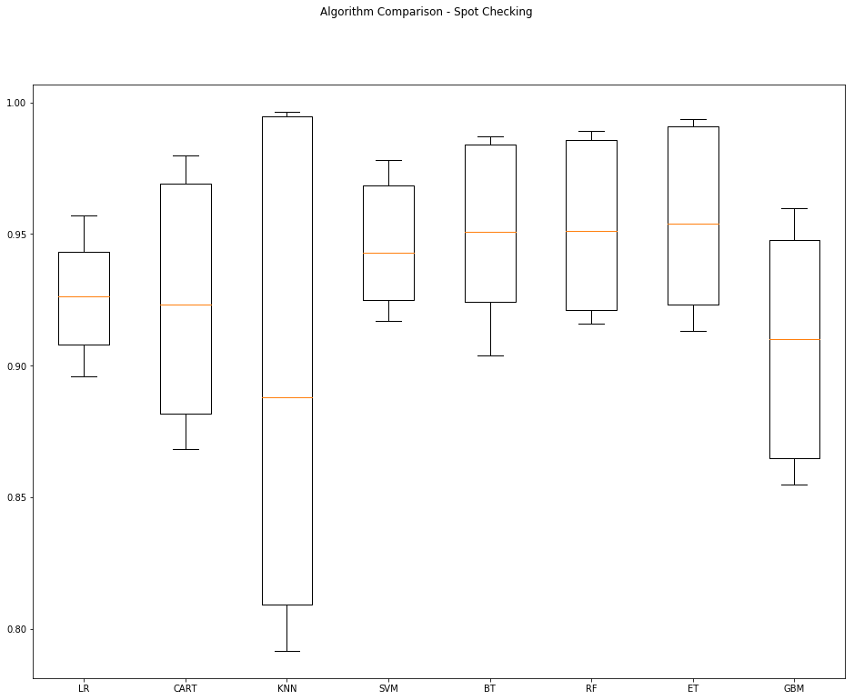

```python
fig = pyplot.figure()
fig.suptitle('Algorithm Comparison - Spot Checking')
ax = fig.add_subplot(111)
pyplot.boxplot(results)
ax.set_xticklabels(names)
pyplot.show()
```

## Section 5 - Improve Accuracy

After we achieve a short list of machine learning algorithms with good level of accuracy, we can leverage ways to improve the accuracy of the models.

### 5.a) Algorithm Tuning

```python
# Set up the comparison array
results = []
names = []
```

```python
# Tuning algorithm #1 - Random Forest
email_notify("Algorithm #1 tuning has begun! "+datetime.now().strftime('%a %B %d, %Y %I:%M:%S %p'))
startTimeModule = datetime.now()
paramGrid1 = dict(n_estimators=np.array([100,200,300,400,500]))
model1 = RandomForestClassifier(random_state=seedNum)
kfold = KFold(n_splits=num_folds, random_state=seedNum)
grid1 = GridSearchCV(estimator=model1, param_grid=paramGrid1, scoring=scoring, cv=kfold)
grid_result1 = grid1.fit(x_train, y_train)

print("Best: %f using %s" % (grid_result1.best_score_, grid_result1.best_params_))
results.append(grid_result1.cv_results_['mean_test_score'])
names.append('RF')
means = grid_result1.cv_results_['mean_test_score']
stds = grid_result1.cv_results_['std_test_score']
params = grid_result1.cv_results_['params']
for mean, stdev, param in zip(means, stds, params):
    print("%f (%f) with: %r" % (mean, stdev, param))
print ('Model training time:',(datetime.now() - startTimeModule))
email_notify("Algorithm #1 tuning completed! "+datetime.now().strftime('%a %B %d, %Y %I:%M:%S %p'))
```

```
Best: 0.959536 using {'n_estimators': 400}
0.957526 (0.036461) with: {'n_estimators': 100}
0.957618 (0.036956) with: {'n_estimators': 200}
0.958623 (0.036106) with: {'n_estimators': 300}
0.959536 (0.035229) with: {'n_estimators': 400}
0.959262 (0.035625) with: {'n_estimators': 500}
Model training time: 0:05:09.884365
```

```python
# Tuning algorithm #2 - Extra Trees
email_notify("Algorithm #2 tuning has begun! "+datetime.now().strftime('%a %B %d, %Y %I:%M:%S %p'))
startTimeModule = datetime.now()
paramGrid2 = dict(n_estimators=np.array([100,200,300,400,500]))
model2 = ExtraTreesClassifier(random_state=seedNum)
kfold = KFold(n_splits=num_folds, random_state=seedNum)
grid2 = GridSearchCV(estimator=model2, param_grid=paramGrid2, scoring=scoring, cv=kfold)
grid_result2 = grid2.fit(x_train, y_train)

print("Best: %f using %s" % (grid_result2.best_score_, grid_result2.best_params_))
results.append(grid_result2.cv_results_['mean_test_score'])
names.append('ET')
means = grid_result2.cv_results_['mean_test_score']
stds = grid_result2.cv_results_['std_test_score']
params = grid_result2.cv_results_['params']
for mean, stdev, param in zip(means, stds, params):
    print("%f (%f) with: %r" % (mean, stdev, param))
print ('Model training time:',(datetime.now() - startTimeModule))
email_notify("Algorithm #2 tuning completed! "+datetime.now().strftime('%a %B %d, %Y %I:%M:%S %p'))
```

```
Best: 0.958166 using {'n_estimators': 200}
0.957709 (0.036572) with: {'n_estimators': 100}
0.958166 (0.036382) with: {'n_estimators': 200}
0.957983 (0.036467) with: {'n_estimators': 300}
0.957801 (0.036505) with: {'n_estimators': 400}
0.957892 (0.036744) with: {'n_estimators': 500}
Model training time: 0:06:19.484547
```

### 5.b) Compare Algorithms After Tuning

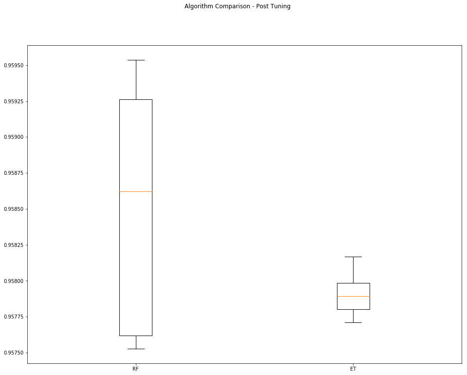

```python
fig = pyplot.figure()
fig.suptitle('Algorithm Comparison - Post Tuning')
ax = fig.add_subplot(111)
pyplot.boxplot(results)
ax.set_xticklabels(names)
pyplot.show()
```

## Section 6 - Finalize Model

Once we have narrow down to a model that we believe can make accurate predictions on unseen data, we are ready to finalize it. Finalizing a model may involve sub-tasks such as:

- Using an optimal model tuned to make predictions on unseen data.
- Creating a standalone model using the tuned parameters
- Saving an optimal model to file for later use.

```python
email_notify("Model Validation and Final Model Creation has begun! "+datetime.now().strftime('%a %B %d, %Y %I:%M:%S %p'))
```

### 6.a) Predictions on validation dataset

```python
validationModel = RandomForestClassifier(n_estimators=400, random_state=seedNum)
validationModel.fit(x_train, y_train)
predictions = validationModel.predict(x_test)
print(accuracy_score(y_test, predictions))
print(f1_score(y_test, predictions, average='micro'))
print(confusion_matrix(y_test, predictions))
print(classification_report(y_test, predictions))
```

```
0.9165
0.9165
[[3641  121]
 [ 213   25]]
              precision    recall  f1-score   support

           0       0.94      0.97      0.96      3762
           1       0.17      0.11      0.13       238

   micro avg       0.92      0.92      0.92      4000
   macro avg       0.56      0.54      0.54      4000
weighted avg       0.90      0.92      0.91      4000
```

### 6.b) Create a standalone model on the entire dataset

```python
startTimeModule = datetime.now()
finalModel = RandomForestClassifier(n_estimators=400, random_state=seedNum)
#x_original = x_train.append(x_test, ignore_index=True)
#y_original = y_train.append(y_test, ignore_index=True)
#finalModel.fit(x_original, y_original)
finalModel.fit(x_train, y_train)
print ('Model training time:',(datetime.now() - startTimeModule))
```

```
Model training time: 0:00:08.178010
```

### 6.c) Save model for later use

```python
# modelName = 'finalModel_BinaryClass.sav'
# dump(finalModel, modelName)
```

```python
email_notify("Model Validation and Final Model Creation completed! "+datetime.now().strftime('%a %B %d, %Y %I:%M:%S %p'))
print ('Total time for the script:',(datetime.now() - startTimeScript))
```

```
Total time for the script: 0:15:35.224726
```